# Advanced Bioinformatics 2023 Assessment

m2207549

## 3.1 Using the sum() function and : operator, write an expression in the code snippet to evaluate the sum of all integers between 5 and 55

The sum function is used to add integers together whilst the two numbers in the brackets separated by : indicate the starting and end number for which all integers between should be added together.

```r
result <- sum(5:55)
result
```

```
## [1] 1530
```

## 3.2 Write a function called sumfun with one input parameter, called n, that calculates the sum of all integers between 5 and n. Use the function to do the calculation for n = 10, n = 20, and n = 100 and present the results.

```r
# First the sumfun function is defined as n

sumfun <- function(n)
  # Then the sum of integers from 5 to n is calculated

  result <- sum(5:n)

  return(result)
```

```
## [1] 1530
```

```r
# Call the sumfun function with the three specified different values of n

n_values <- c(10, 20, 100)

sum_values <- sapply(n_values, sumfun)

# A data frame is then created to store the results

results_df <- data.frame(n = n_values, sum = sum_values)

#Finally the results are presented in the following table

knitr::kable(results_df, caption = "Sum of Integers between 5 and n")
```

Sum of Integers between 5 and n

| n | sum |
| --- | --- |
| 10 | 45 |
| 20 | 200 |
| 100 | 5040 |

## 3.3. The famous Fibonacci series is calculated as the sum of the two preceding members of the sequence, where the first two steps in the sequence are 1, 1. Write an R script using a for loop to calculate and print out the first 12 entries of the Fibonacci series.

```r
# The variables for the first two numbers; 1,1 in the Fibonacci series are labelles as n1 and n2

n1 <- 1
n2 <- 1

# The first two numbers of the series are printed using the cat function and that the two numbers are separated by a comma

cat(n1, n2, sep = ", ")
```

```
## 1, 1
```

```r
# Issue a loop with the for command to calculate and print the next 10 numbers in the series. 3 and 12 are placed in brackets in order to signify that the series should start from the 3rd integer (since the first two integers are given) and go up until the 12th.

for (i in 3:12) {
  # The next integer in the series is calculated as the sum of the two preceding integers using next_num (where the first two integers have been defined as n1 and n2.)

  next_num <- n1 + n2

  # Similarly to previously done, the next number is printed using the cat function

  cat(", ", next_num)

  # n1 and n2 are then set for the next iteration of the loop

  n1 <- n2
  n2 <- next_num
  # As such, the series is seen below:
}
```

```
## ,  2,  3,  5,  8,  13,  21,  34,  55,  89,  144
```

## 3.4 With the mtcars dataset bundled with R, use ggplot to generate a box of miles per gallon (in the variable mpg) as a function of the number of gears (in the variable gear). Use the fill aesthetic to colour bars by number of gears.

```r
# First the ggplot library is obtained

library(ggplot2)
# Then the mtcars dataset is obtained and viewed

data(mtcars)

mtcars
```

```
##                      mpg cyl  disp  hp drat    wt  qsec vs am gear carb
## Mazda RX4           21.0   6 160.0 110 3.90 2.620 16.46  0  1    4    4
## Mazda RX4 Wag       21.0   6 160.0 110 3.90 2.875 17.02  0  1    4    4
## Datsun 710          22.8   4 108.0  93 3.85 2.320 18.61  1  1    4    1
## Hornet 4 Drive      21.4   6 258.0 110 3.08 3.215 19.44  1  0    3    1
## Hornet Sportabout   18.7   8 360.0 175 3.15 3.440 17.02  0  0    3    2
## Valiant             18.1   6 225.0 105 2.76 3.460 20.22  1  0    3    1
## Duster 360          14.3   8 360.0 245 3.21 3.570 15.84  0  0    3    4
## Merc 240D           24.4   4 146.7  62 3.69 3.190 20.00  1  0    4    2
## Merc 230            22.8   4 140.8  95 3.92 3.150 22.90  1  0    4    2
## Merc 280            19.2   6 167.6 123 3.92 3.440 18.30  1  0    4    4
## Merc 280C           17.8   6 167.6 123 3.92 3.440 18.90  1  0    4    4
## Merc 450SE          16.4   8 275.8 180 3.07 4.070 17.40  0  0    3    3
## Merc 450SL          17.3   8 275.8 180 3.07 3.730 17.60  0  0    3    3
## Merc 450SLC         15.2   8 275.8 180 3.07 3.780 18.00  0  0    3    3
## Cadillac Fleetwood  10.4   8 472.0 205 2.93 5.250 17.98  0  0    3    4
## Lincoln Continental 10.4   8 460.0 215 3.00 5.424 17.82  0  0    3    4
## Chrysler Imperial   14.7   8 440.0 230 3.23 5.345 17.42  0  0    3    4
## Fiat 128            32.4   4  78.7  66 4.08 2.200 19.47  1  1    4    1
## Honda Civic         30.4   4  75.7  52 4.93 1.615 18.52  1  1    4    2
## Toyota Corolla      33.9   4  71.1  65 4.22 1.835 19.90  1  1    4    1
## Toyota Corona       21.5   4 120.1  97 3.70 2.465 20.01  1  0    3    1
## Dodge Challenger    15.5   8 318.0 150 2.76 3.520 16.87  0  0    3    2
## AMC Javelin         15.2   8 304.0 150 3.15 3.435 17.30  0  0    3    2
## Camaro Z28          13.3   8 350.0 245 3.73 3.840 15.41  0  0    3    4
## Pontiac Firebird    19.2   8 400.0 175 3.08 3.845 17.05  0  0    3    2
## Fiat X1-9           27.3   4  79.0  66 4.08 1.935 18.90  1  1    4    1
## Porsche 914-2       26.0   4 120.3  91 4.43 2.140 16.70  0  1    5    2
## Lotus Europa        30.4   4  95.1 113 3.77 1.513 16.90  1  1    5    2
## Ford Pantera L      15.8   8 351.0 264 4.22 3.170 14.50  0  1    5    4
## Ferrari Dino        19.7   6 145.0 175 3.62 2.770 15.50  0  1    5    6
## Maserati Bora       15.0   8 301.0 335 3.54 3.570 14.60  0  1    5    8
## Volvo 142E          21.4   4 121.0 109 4.11 2.780 18.60  1  1    4    2
```

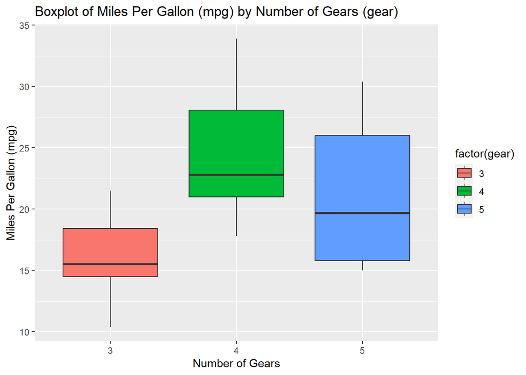

```r
# A boxplot is created using ggplot for the mtcars dataset. The x and y functions are used to set miles per gallon as a function of number of gears. The fill function is used to ensure that the number of gears are colored in the boxplot.
# The labs function is used to ensure that each component of the boxplot is labelled

ggplot(mtcars, aes(x = factor(gear), y = mpg, fill = factor(gear))) +
  geom_boxplot() +
  labs(title = "Boxplot of Miles Per Gallon (mpg) by Number of Gears (gear)",
       x = "Number of Gears",
       y = "Miles Per Gallon (mpg)")
```

## 3.5.Using the cars dataset and the function lm, fit a linear relationship between speed and breaking distance in the variable distance. What are the fitted slope and intercept of the line, and their standard errors? What are the units used for the variables in the dataset?

```r
# Load the mtcars dataset

data(cars)

#Display of dataset shows that the units for speed and distance are not included. As such it may be assumed that speed is in miles per hour and distance is in feet based on the values and context of the raw data

cars
```

```
##    speed dist
## 1      4    2
## 2      4   10
## 3      7    4
## 4      7   22
## 5      8   16
## 6      9   10
## 7     10   18
## 8     10   26
## 9     10   34
## 10    11   17
## 11    11   28
## 12    12   14
## 13    12   20
## 14    12   24
```

[output cut: 36 more lines]

```r
# The lm_model function allows for a linear regression relationship to be formed between stopping distance and speed for the cars in the dataset

lm_model <- lm(dist ~ speed, data = cars)

# Coefficients are calculated frok the linear regression model by defining the two parameters: intercept and slope. The final line calculates the standard error of the two coefficients provided.

coefficients <- coef(lm_model)
intercept <- coefficients[1]
slope <- coefficients[2]
se <- sqrt(diag(vcov(lm_model)))

# To print the results of the intercept and slope as well as the standard errors of the two coefficients; the cat function is used.
cat("Intercept: ", intercept, "\n")
```

```
## Intercept:  -17.57909
```

```r
cat("Slope: ", slope, "\n")
```

```
## Slope:  3.932409
```

```r
cat("Standard Error (Intercept): ", se[1], "\n")
```

```
## Standard Error (Intercept):  6.75844
```

```r
cat("Standard Error (Slope): ", se[2], "\n")
```

```
## Standard Error (Slope):  0.4155128
```

## 3.6. Use ggplot to plot the data points from Task 3.5. and the linear fit.

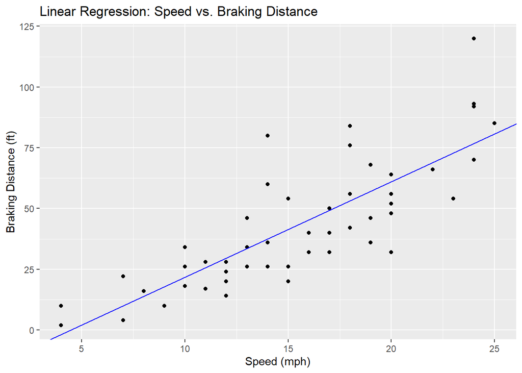

```r
# Data is plotted using ggplot with firstly the x and y axis being defined as speed and distance respectively. Aspects such as naming of aspects of the graph such as intercept and slope are also included as well as colour of the line of best fit and title of the graph.

ggplot(cars, aes(x = speed, y = dist)) +
  geom_point() +
  geom_abline(intercept = intercept, slope = slope, color = "blue") +
  labs(title = "Linear Regression: Speed vs. Braking Distance",
       x = "Speed (mph)",
       y = "Braking Distance (ft)")
```

## 3.7. Again using the cars dataset, now use linear regression (lm) to estimate the average reaction time for the driver to start breaking (in seconds). To simplify matters you may assume that once breaking commences, breaking distance is proportional to the square of the speed. Explain the steps in your analysis. Do you get reasonable results? Finally, use ggplot to plot the data points and the fitted relationship.

```r
# Braking distance was calculated assuming that breaking distance is proportionate to the square of speed
braking_distance_squared <- cars$speed^2

# A linear regression model was then fitted for braking distance and speed in the cars dataset
lm_model <- lm(braking_distance_squared ~ speed, data = cars)

# Extraction of intercept and slope coefficients labelled as coef1 and coef2
intercept <- coef(lm_model)[1]
slope <- coef(lm_model)[2]

# Calculation for estimated average reaction time
reaction_time <- sqrt(intercept)
# Print results shows that no number was produced for the estimated average reaction time due to warning insqrt intercept. This may be caused by the fact that the intercept doesn't go through 0, thus calculating a squared negative.
cat("Estimated Average Reaction Time (seconds): ", reaction_time, "\n")
```

```
## Estimated Average Reaction Time (seconds):  NaN
```

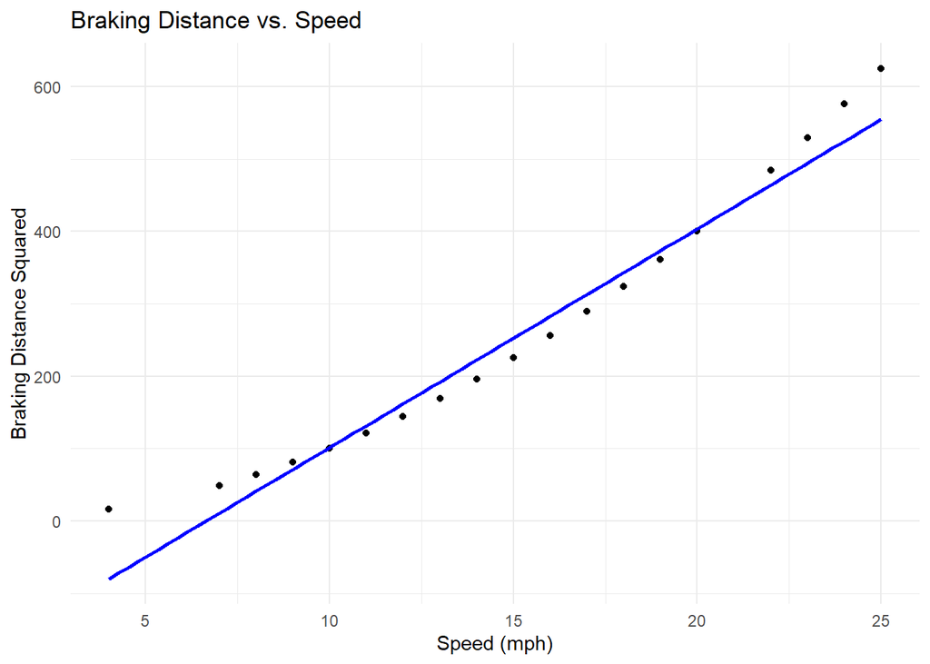

```r
# Use ggplot to plot the data points and fitted relationship
library(ggplot2)

# ggplot function was used to define and the x and y axis of the plot as well as the title for the graph. The graph indicates a strong positive correlation between speed and braking distance squared.
ggplot(cars, aes(x = speed, y = braking_distance_squared)) +
  geom_point() +  # Add data points
  geom_smooth(method = "lm", formula = y ~ x, se = FALSE, color = "blue") +  # Add fitted line
  labs(title = "Braking Distance vs. Speed", x = "Speed (mph)", y = "Braking Distance Squared") +
  theme_minimal()
```

# RNA-seq assessment

```r
#setting and verifying the current working directory

setwd("C:/Users/Alex/Documents")

getwd()
```

```
## [1] "C:/Users/Alex/Documents"
```

## 3.8.Read in count data and sample description.

```r
#Read count information

all_counts <- read.csv(file = "C:/Users/Alex/Documents/exercise1_counts.csv", header = T, row.names =1)
head(all_counts)
```

```
##           control_FFa1.bam control_FFa2.bam control_FFa3.bam mutant_KOa1.bam
## 497097                  16               16                0              21
## 100503874               20                0                0              64
## 100038431                0                0                2               0
## 19888                   11                0               10             113
## 20671                   14               16                0              40
## 27395                  465              193              596             436
##           mutant_KOa2.bam mutant_KOa3.bam mutant_KOb1.bam mutant_KOb2.bam
## 497097                 16              27              20               0
## 100503874               0               4               5               0
## 100038431               0               8               0               0
## 19888                   0              26              14               6
## 20671                   8              33              33              12
## 27395                 686             572            1378            1901
##           mutant_KOb3.bam
## 497097                  2
## 100503874               2
## 100038431               0
## 19888                  16
## 20671                  24
## 27395                1553
```

```r
#Read the sample description

sam_des <- read.table("C:/Users/Alex/Documents/exercise1_sample_description.info", sep = "\t", header = TRUE)
head(sam_des)
```

```
##              filename sample condition batch
## 1    control_FFa1.bam   FFa1       FFa     a
## 2    control_FFa2.bam   FFa2       FFa     b
## 3    control_FFa3.bam   FFa3       FFa     c
## 4 TMC_mutant_KOa1.bam   KOa1       KOa     a
## 5 TMC_mutant_KOa2.bam   KOa2       KOa     b
## 6 TMC_mutant_KOa3.bam   KOa3       KOa     c
```

## 3.9. Create col_data and check dimensions

```r
#Creating col_data from sample description

col_data <- data.frame(sample = sam_des$sample, condition = sam_des$condition, batch = sam_des$batch)
head(col_data)
```

```
##   sample condition batch
## 1   FFa1       FFa     a
## 2   FFa2       FFa     b
## 3   FFa3       FFa     c
## 4   KOa1       KOa     a
## 5   KOa2       KOa     b
## 6   KOa3       KOa     c
```

```r
#Check dimensions

all(colnames(all_counts) == col_data$name)
```

```
## [1] TRUE
```

## 3.10. Construct DESeqDataSet object using count data and sample description

```r
#Load DESeq2 library

suppressPackageStartupMessages(library(DESeq2))
#Create DESeq object

dds <- DESeqDataSetFromMatrix(countData = all_counts, colData = col_data, design =~ condition)
dds
```

```
## class: DESeqDataSet
## dim: 26301 9
## metadata(1): version
## assays(1): counts
## rownames(26301): 497097 100503874 ... 100040384 100040400
## rowData names(0):
## colnames(9): control_FFa1.bam control_FFa2.bam ... mutant_KOb2.bam
##   mutant_KOb3.bam
## colData names(3): sample condition batch
```

## 3.11. Perform rlog and VST transformation on the data

```r
#Performing rlog

rld <- rlog(dds)

#Performing VST transformation

vst <- varianceStabilizingTransformation(dds)
```